# FUNCION DE DAÑO

Jorge Martelo

25/5/2021

### Introduccion

Este ejercicio aplica la metodología de la función de daño a través del método de costos evitados, para estimar los costos económicos incurridos por una empresa de agua potable producto de la sedimentación ocasionada por una deforestación del 10% del Bosque de la cuenca que surte de agua a esta planta. El fenomeno de la desforestación trae consigo efectos sobre el aumento de la carga de sedimentos y la reduccion del caudal medio, los cuales generan sobrecostos a la empresa.

### Variables utilizadas

**Variables de daño**: Miden como los cambios en la cobertura boscosa afectan el nivel de sedimentos y el caudal medio

- Producción de Sedimentos en Ton/mes.
- Caudal medio Mensual en m3 /seg
- Porcentaje de Area Deforestada (10% por defecto)

**Variables fisicas**: Representan la relacion entre cambios en la cobertura boscosa y la calidad del agua

- Caudal Mensual Medio en m3/seg
- Cantidad de Sedimentos mg/lt

**Variables de reaccion:** Miden los cambios en la planta ante un cambio en la calidad ambiental.

- Cantidad de Sulfato de Aluminio y Cal en Kg/mes
- Turbiedad medida en unidades nefelométricas de Turbiedad
- Cantidad de Agua Tratada en m3/mes

### Caso de estudio: Analisis de sedimentos

Como se mencionó anteriormente, la desforestacion genera diferentes consecuciencias sobre la calidad del agua, sin embargo, para efectos del ejercicio se analizará la sedimentacion y turbiedad.

Diferentes investigaciones han estimado que el desforestar 1% genera un 100% de incremento en los sedimientos. Por otro lado, en el caso de turbiedad se debe estimar cual ha sido la relacion entre esta variable y sedimentacion de la siguiente manera:

$$\hat{T} = \hat{\rho} S^{\hat{\beta_1}}$$

Donde $\hat{T}$ es el nivel de turbiedad de agua, $S$ es el nivel de sedimentacion, $\hat{\rho}$ es un parametro que indica el nivel de turbiedad del agua independientemente del nivel de sedimentacion y $\hat{\beta_1}$ es el impacto de la sedimentacion sobre la turbiedad. Dado que el metodo de minimos cuadrados ordinarios supone linealidad, debemos reescribir la funcion de la siguiente forma:

$$ln(\hat{T}) = ln(\hat{\rho} S^{\hat{\beta_1}})$$
$$ln(\hat{T}) = ln(\hat{\rho}) + ln(S^{\hat{\beta_1}})$$

$$ln(\hat{T}) = ln(\hat{\rho}) + \hat{\beta_1}ln(S)$$

Una vez determinada la relacion entre la sedimentacion y la turbiedad, se debe estimar el efecto negativo que este fenomeno trae para la empresa: un incremento en la turbiedad impacta directamente sobre la mano de obra y en la cantidad de insumos para tratar el agua. Para efectos del ejercicio solo se estimará esta relacion para el gasto en quimicos

$$\hat{Q} = \hat{\lambda} T^{\hat{\alpha_1}}$$

Donde $\hat{Q}$ es el gasto promedio en quimicos para tratar el agua de acuerdo a un nivel de turbiedad $S$, $\hat{\lambda}$ es un parametro que indica el gasto en quimicos con independencia del nivel de Turbiedad y $\hat{\alpha_1}$ representa la relacion entre el nivel de Turbiedad y el gasto en quimicos. Como el caso anterior, se puede reescribir para cumplir el supuesto de normalidad de la siguiente forma:

$$ln(\hat{Q}) = ln(\hat{\lambda}) + \hat{\alpha_1}ln(T)$$

### Desarrollo del problema

De acuerdo a la informacion presentada anteriormente, desarrolle los siguientes puntos:

#### 1. Cargue la base de datos a R con el nombre de FD

```r
library(readxl)
FD <- read_excel("C:/Users/marteloa.5/Google Drive/Teleperformance/Sesiones de R/Funcion de daño/DAMAGE.xlsx")
```

**Decodificacion de las variables**:

- TURB: Tubiedad del agua
- SED: Sedimentacion
- CQUIM: Gasto promedio en quimicos

#### 2. Seleccione las variables relevantes para el analisis y realice un resumen descriptivo. Comente los resultados

```r
library(dplyr)
FD2 <- FD %>% select(TURB, SED, CQUIM)
summary(FD2)
```

```
##       TURB             SED             CQUIM
##  Min.   : 0.960   Min.   :124355   Min.   :0.3595
##  1st Qu.: 3.706   1st Qu.:235474   1st Qu.:1.7357
##  Median : 9.355   Median :345554   Median :3.5630
##  Mean   :12.138   Mean   :372451   Mean   :3.7603
##  3rd Qu.:14.791   3rd Qu.:507746   3rd Qu.:5.5324
##  Max.   :53.100   Max.   :852206   Max.   :7.9196
```

#### 3. Realice un grafico de dispersion entre la sedimentacion y la turbiedad del agua, ¿Que puede concluir?.Existe algun valor anormal en el nivel de sedimentacion de agua?

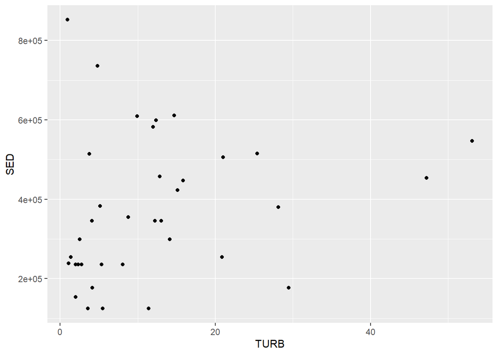

```r
library(ggplot2)
ggplot(FD2)+
  aes(x = TURB, y = SED)+
  geom_point()
```

#### 4. Transforme las variables de acuerdo a la especificacion del modelo turbiedad vs sedimentacion

```r
FD2$logturb <- log(FD2$TURB)
FD2$logsedi <- log(FD2$SED)
```

#### 5. Estime el modelo que relaciona la turbiedad en funcion de la sedimentacion. Interprete el signo y la magnitud del coeficiente

```r
modelo1 <- lm(data = FD2,
              logturb ~ logsedi)
summary(modelo1)
```

```
##
## Call:
## lm(formula = logturb ~ logsedi, data = FD2)
##
## Residuals:
##     Min      1Q  Median      3Q     Max
## -2.5848 -0.8369  0.1545  0.6002  1.7029
##
## Coefficients:
##             Estimate Std. Error t value Pr(>|t|)
## (Intercept)  -4.9476     4.2567  -1.162    0.253
## logsedi       0.5486     0.3347   1.639    0.110
##
## Residual standard error: 1.019 on 34 degrees of freedom
## Multiple R-squared:  0.07322,    Adjusted R-squared:  0.04596
## F-statistic: 2.686 on 1 and 34 DF,  p-value: 0.1105
```

#### 6. Transforme las variables de acuerdo a la especificacion del modelo Gasto en quimicos vs turbiedad

```r
FD2$logquim <- log(FD2$CQUIM)
```

#### 7. Estime el modelo que relaciona el gasto en fucion de la turbiedad. Interprete el signo y la magnitud del coeficiente.

```r
modelo2 <- lm(data = FD2,
              logquim ~ logturb)
summary(modelo2)
```

```
##
## Call:
## lm(formula = logquim ~ logturb, data = FD2)
##
## Residuals:
##      Min       1Q   Median       3Q      Max
## -0.77185 -0.21892 -0.00599  0.24325  0.78512
##
## Coefficients:
##             Estimate Std. Error t value Pr(>|t|)
## (Intercept) -0.30060    0.13385  -2.246   0.0313 *
## logturb      0.68358    0.05897  11.592 2.33e-13 ***
## ---
## Signif. codes:  0 '***' 0.001 '**' 0.01 '*' 0.05 '.' 0.1 ' ' 1
##
## Residual standard error: 0.3641 on 34 degrees of freedom
## Multiple R-squared:  0.7981, Adjusted R-squared:  0.7921
## F-statistic: 134.4 on 1 and 34 DF,  p-value: 2.328e-13
```

#### 9. De acuerdo a los resultados obtenidos responda las siguientes preguntas:

**Estimacion efecto deforestacion**

- Si un 1% de desforestacion causa un 100% de incremento en sedimentos, ¿cuanto será el incremento para un 10% de desforestacion?
- ¿Cuanto será el incremento en la turbiedad del agua de acuerdo al incremento en la sedimentacion previamente calculado?
- ¿Cuanto será el incremento en el gasto promedio en quimicos de acuerdo al incremento en la turbiedad previamente calculado?

**Monetizacion**

- Si el costo promedio de tratamientos es $23.5 por M3, en cuanto se incrementará el valor debido al incremento en quimicos?
- Si el promedio de 6 meses del agua tratada fue de 2.665.476 M3, ¿cuanto será el incremento en los costos de tratamiento? Interprete este valor.